# Assignment 6

```r
library(tidyverse)
library(readxl)
```

## Question 1A

The data file shows the rats that were in three of the randomly assigned diet, and their bone density that was measured. Although there are 15 observations for each treatment the date file is displaying this in a untidy manner. We want to tidy this up so it displays it cleanly in one column with corresponding treatment row.

## Question 1B

First we read the data table into a preview and notice how untidy it appears.

```r
my_url <- "http://ritsokiguess.site/STAC32/isoflavones.txt"
rats <- read_table(my_url)
rats
```

| treatment | bone_mineral_density |
| --- | --- |
| control | 228 207 234 220 217 228 |
|  | 209 221 204 220 203 219 |
|  | 218 245 210 |
| low_dose | 211 220 211 233 219 233 |
|  | 226 228 216 225 200 208 |
|  | 198 208 203 |
| high_dose | 250 237 217 206 247 228 |
|  | 245 232 267 261 221 219 |
|  | 232 209 255 |

```r
rats %>% separate_rows(bone_mineral_density) %>%
  mutate(treatment = na_if(treatment, "")) %>%
  fill(treatment) -> separatedrats
separatedrats$bone_mineral_density <- as.numeric(separatedrats$bone_mineral_density)
separatedrats
```

| treatment | bone_mineral_density |
| --- | --- |
| control | 228 |
| control | 207 |
| control | 234 |
| control | 220 |
| control | 217 |
| control | 228 |
| control | 209 |
| control | 221 |
| control | 204 |
| control | 220 |

[output cut: 35 more lines]

## Question 1C

The statistician of this study is debating on using an ordinary analysis of variance to compare the bone mineral density of different treatments. Obtaining a suitable plot based on the data we have will help her decide if this is a good idea. We will use a side-by-side boxplot since there is one categorical and quantitative variable.

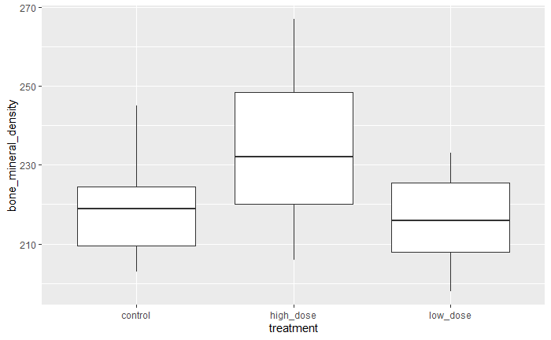

```r
ggplot(separatedrats, aes(treatment,bone_mineral_density)) + geom_boxplot()
```

The plot appears to be normal with no outliers being present in the control, high dose and low dose treatments. Therefore an ANOVA test is possible as the samples are normal enough.

## Question 1D

Previously, we determined that an ANOVA test is possible due to the sample being normal enough but the spread being equal enough will help us decide whether to use a Welch ANOVA or a regular ANOVA. Thus we plot an addiotional graph of a normal quantile plot between 3 groups of data and check for equal spread.

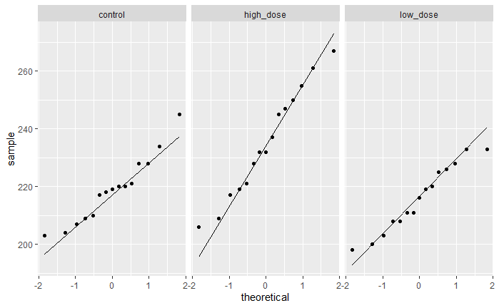

```r
ggplot(separatedrats, aes(sample = bone_mineral_density)) + stat_qq() +
  stat_qq_line() + facet_wrap( ~ treatment )
```

The three plot shows that the spread is not equal enough between the three treatment groups. Therefore I would recommend using a Welch Anova test as the samples are normal enough but the spread is not equal enough.

## Citations

Separate a collapsed column into multiple rows - separate_rows. (n.d.). Retrieved March 12, 2021, from https://tidyr.tidyverse.org/reference/separate_rows.html

Fill in missing values with previous or next value - fill. (n.d.). Retrieved March 12, 2021, from https://tidyr.tidyverse.org/reference/fill.html